# Alzheimer’s Project Report

Author

Bijo Varghese, Hong Fu and Jessica Kentwell

Published

November 8, 2024

## Overview of the Problem

It is estimated that 30% of older adults aged 60 and above die from Alzheimer’s disease, a common and progressive neurodegenerative disorder that primarily affects memory, thinking, and behavior [1]. Alzheimer’s is the leading cause of dementia, a term used to describe severe cognitive decline that interferes with daily life. So far the exact cause of Alzheimer’s is not fully understood, as it involves a complex interaction of genetic, environmental, and lifestyle factors. Typically, Alzheimer’s begins with mild memory loss, especially affecting recent memories, but it progressively worsens, leading to more severe symptoms such as confusion, language difficulties, impaired problem-solving, mood swings, personality changes, and challenges with daily tasks.

One of the critical issues with Alzheimer’s is the lack of a definitive diagnostic test; diagnosis is currently based on clinical history and observed symptoms. Early detection is essential, yet without a conclusive diagnostic method, it remains challenging. To address this, it is vital to develop an effective diagnostic approach that can identify early symptoms using readily accessible patient data and medical histories.

Our primary goal is to develop a right-sized predictive model with adequate performance capable of classifying individuals as having or not having Alzheimer’s based on clinical patient data. Additionally, we aim to identify the specific factors or combinations of factors that can reliably aid in predicting Alzheimer’s disease.

## Alzheimer’s Disease Dataset

We selected a dataset from Kaggle to develop our predictive model. This dataset is highly comprehensive and contains synthetic data, offering extensive health information for **2149** patients. The dataset includes demographic details, lifestyle factors, medical history, clinical measurements, cognitive and functional assessments, symptoms, and a binary diagnosis of Alzheimer’s Disease - total of **36** features.

With the richness in features, we have many variables to consider for our model. The chosen dataset is primed for researchers and data scientists aiming to explore factors associated with Alzheimer’s, develop predictive models, and perform in-depth statistical analyses. The table below provides a breakdown of these features in its raw form, with Patient and Doctor ID removed.

##### Table 1. Feature description and data type for Alzheimer’s disease dataset

| Variables | Description | Data Type |
| --- | --- | --- |
| Age | Age of the patient, ranges from 60 to 90 years. | interval |
| Gender | Gender of the patients, 0: Male, 1: Female | nominal |
| Ethnicity | Ethnicity of the patients, 0: Caucasian, 1: African American, 2: Asian, 3: Other | nominal |
| EducationLevel | Education level of the patients, 0: None, 1: High School, 2: Bachelor's, 3: Higher | ordinal |
| BMI | BMI, ranging from 15 to 40 | ratio |
| Smoking | Smoking status, 0: No, 1: Yes | nominal |
| AlcoholConsumption | Weekly alcohol consumption in units, ranging from 0 to 20 | ratio |
| PhysicalActivity | Weekly physical activity in hours, ranging from 0 to 10 | ratio |
| DietQuality | Diet quality score, ranging from 0 to 10 | ratio |
| SleepQuality | Sleep quality score, ranging from 4 to 10 | ratio |
| FamilyHistoryAlzheimers | Family history of Alzheimer's Disease, 0: No, 1: Yes | nominal |
| CardiovascularDisease | Presence of cardiovascular disease, 0: No, 1: Yes | nominal |
| Diabetes | Presence of diabetes, 0: No, 1: Yes | nominal |
| Depression | Presence of depression, 0: No, 1: Yes | nominal |
| HeadInjury | History of head injury, 0: No, 1: Yes | nominal |
| Hypertension | Presence of hypertension, 0: No, 1: Yes | nominal |
| SystolicBP | Systolic blood pressure, ranging from 90 to 180 mmHg | interval |
| DiastolicBP | Diastolic blood pressure, ranging from 60 to 120 mmHg | interval |
| CholesterolTotal | Total cholesterol levels, ranging from 150 to 300 mg/dL | interval |
| CholesterolLDL | Low-density lipoprotein cholesterol levels, ranging from 50 to 200 mg/dL. | interval |
| CholesterolHDL | High-density lipoprotein cholesterol levels, ranging from 20 to 100 mg/dL. | interval |
| CholesterolTriglyerides | Triglycerides levels, ranging from 50 to 400 mg/dL | interval |
| MMSE | Mini-Mental State Examination score, ranging from 0 to 30. Lower scores indicate cognitive impairment. | ordinal |
| FunctionalAssessment | Functional assessment score, ranging from 0 to 10. Lower scores indicate greater impairment. | ordinal |
| MemoryComplaints | Presence of memory complaints, 0: No, 1: Yes | nominal |
| BehavioralProblems | Presence of behavioral problems, 0: No, 1: Yes | nominal |
| ADL | Activities of Daily Living score, ranging from 0 to 10. Lower scores indicate greater impairment. | ordinal |
| Confusion | Presence of confusion, 0: No, 1: Yes | nominal |
| Disorientation | Presence of disorientation, 0: No, 1: Yes | nominal |
| PersonalityChanges | Presence of personality changes, 0: No, 1: Yes | nominal |
| DifficultyCompletingTasks | Presence of difficulty completing tasks, 0: No, 1: Yes | nominal |
| Forgetfulness | Presence of forgetfulness, 0: No, 1: Yes | nominal |
| Diagnosis | Diagnosis status for Alzheimer's Disease, 0: No, 1: Yes | nominal |

## Initial Data Analysis

In our initial data analysis, we found that we had a complete dataset with no missing values. In Figure 1, we can see how the dataset is imbalanced towards patients diagnosed with No Alzheimers. Due to notable imbalance in the dataset, we adjusted our classification performance evaluation accordingly, which we’ll share later in the report. To further understand the relationship between the various numeric features, we also constructed a Pearson correlation matrix. Through Figure 2, we established that the features have negligible collinearity. Finally, to observe the distribution of the diagnosis for each feature, we explored a violin plot in Figure 3, that suggested a normal distribution for most of features - except for MMSE, Functional Assessment and ADL. Figure 3 also illustrates that there are no obvious outliers or anomalous values. Identifying and managing such outliers is crucial, as they could skew model performance if the model learns from extreme values, potentially hindering its ability to generalise effectively.

##### Figure 1. Percentage of frequencies in each class

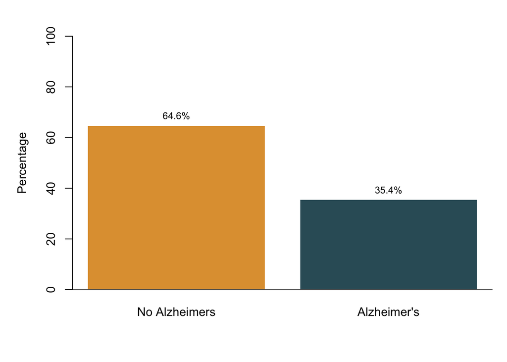

##### Figure 2. Correlation heatmap of numeric predictor variables

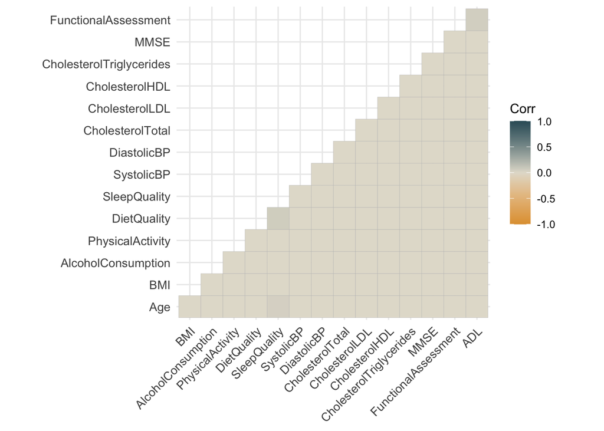

##### Figure 3. Numeric predictor variables by diagnosis

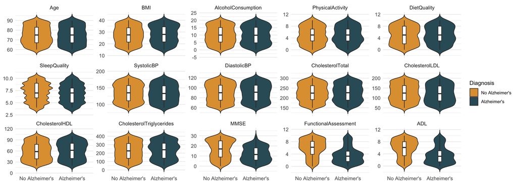

## Feature Engineering

To prepare the dataset for modelling, the raw data was transformed into a consistent format and saved as an RDS file. All binary predictor variables were converted to numeric values (0 and 1). The target variable was converted into a factor with two levels: ‘Alzheimers’ and ‘No_Alzheimers’. Categorical variables such as “EducationLevel” and “Ethnicity” were dummy encoded to maintain the numeric format required for modelling. After dummy encoding, we had **36** predictor variables. We included all of these in our models as predictors. In the context of our classification problem, each variable contributes clinical information that may be valuable.

We also used `caret` to scale and normalise our predictor variables using the `preProcess` function. Our dataset had some class imbalance, with 65% of patients not having Alzheimer’s and 35% with Alzheimer’s disease. Class imbalance can adversely impact model performance when it comes to predicting the minority class [2]. To lessen this impact, we adjusted the default probability threshold from 0.5 to 0.35 for classifying a patient as having Alzheimer’s disease.

## Classification Algorithms used

To help us solve our classification problem, we chose 4 models - random forest (RF), logistic regression with Lasso regularisation (Lasso), linear discriminant analysis (LDA) and $k$-nearest neighbours ($k$NN), each with it’s own unique strengths. For each model, relevant hyperparameters were used to tune the model.

- **Lasso Model**: For the Lasso model, we optimized the `lambda` parameter to control the regularisation strength. High lambda values lead to simpler models by shrinking coefficients to zero, while low values retain more predictors. We used cross-validation with different `lambda` values to find the best balance between bias and variance. To automate this process, we performed a grid search across a range of 10 `lambda` values (0.001 to 0.1) to identify the optimal choice. Since Lasso is sensitive to feature scales, standardising the data is essential. For the Lasso model, we need to optimise the `lambda` parameter. High `lambda` values lead to simpler models by shrinking coefficients to zero, while low values retain more predictors. We use cross-validation with different `lambda` values to find the best balance between bias and variance. The `alpha` hyperparameter was set to 1 which means a total Lasso. The best tuned `lambda` in the Lasso model was **0.023**.
- **Random Forest**: We also trained and tested a decision tree model to inspect the region where a patient belongs and predict the most commonly occurring class in that region. To improve these predictions, we extended the tree to a Random Forest by training our model on an ensemble of trees - 1, 50, 100, 250 and 500. To further tune the model, we also trained the model on various `mtry` parameters - 1, 6, 11, 16, 21, 26, 31 and 36, to find the best $m$ predictors at each split. The best tuned `mtry` parameter for the random forest was **6** and we found the best performing ensemble of trees to be **100**.
- **kNN**: $k$NN is a non-parametric method that classifies a data point based on the majority class of its $k$ closest neighbors in the feature space. The hyperparameter for the number of neighbours was tuned using a odd number grid search in `caret` where values 9, 11, 21, 109, 199, 273, 313, 355 and 409 were explored. We found the best $k$ to be **21** based on the highest F1 score.
- **LDA**: LDA is a simple model that searches for a linear combination of features that can separate classes or groups. It is effective when the classes are well-separated. It assumes that predictors are normally and linearly distributed. It does not have any hyperparameters to tune but we confirmed that the distributions of the predictor variables were relatively normally distributed.

##### Cross-validation

To ensure generalisation of our chosen models to the test data, we used 10-fold cross-validation with 10 repeats. We implemented this by using a common `trainControl` object (from `caret`) that used a grid search for hyperparameter tuning. This allows us to compare our model performance fairly as the cross-validation folds have remained consistent. We initially set our `tuneLength` = 10 to let `caret` generate the hyperparameter settings. To determine the variability and consistency of our models on the cross validated folds, we used the `resamples` function to compare their performance.

## Classification Performance Evaluation

#### Performance metrics

In order to evaluate the performance of our models, we utilised a variety of metrics to help us choose the best model.

- **Accuracy**: It is the proportion of the correct predictions made out of the total predictions made by the model. An accuracy value of 1 means that the model made all its predictions correctly. It is not the best metric to use when classes are imbalanced.
- **AUC** (Area Under the ROC Curve): It measures a model’s ability to differentiate between classes, if the value is close to 1, it means it has high classification power. If the AUC is value is closer to 0.5, the model is performing at the same level as guessing.
- **Recall/Sensitivity** (True Positive Rate): It indicates what number of actual positive cases had been correctly identified by the model. For our problem, it is the measure of how well the model is able to classify patients with Alzheimer’s disease. A Recall value closer to 1 reduces the chances of false negatives, i.e, classifying a positive Alzhiemer’s patient as negative.
- **Precision** (Positive Predictive Value): The proportion of positive predictions that are actually correctly. Lower Precision raises the rate of false positives — incorrectly identifying a person without Alzheimer’s as having Alzheimer’s.
- **F1 score**: Mean of precision and recall. It is a single score that gives a balance between Precision and Recall. A F1 score of 1 means the model correctly classifies all Alzheimer’s patients with no false positives or false negatives. F1 is a more informative metric than Accuracy when classes are imbalanced, especially when the positive class is the minority class
- **Specificity**: It indicates how well the model can predict actual negative cases.

#### Cross-validation results

##### Figure 4. Model performance on training data

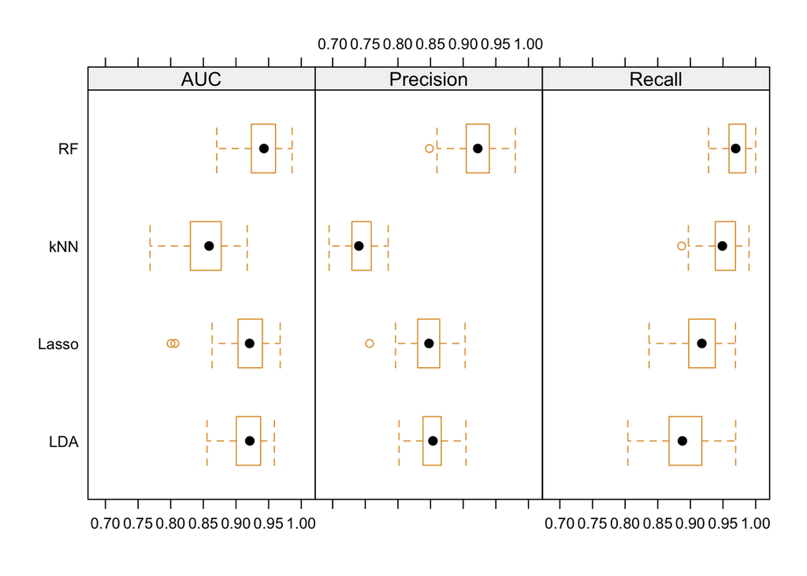

#### Test Data results

##### Figure 5. Model performance on test data

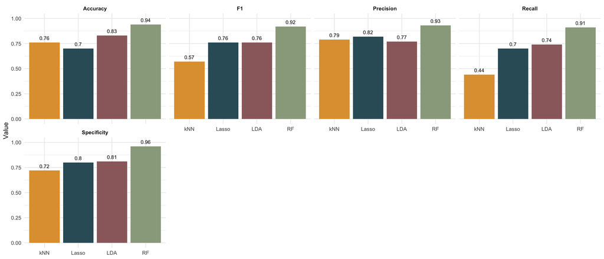

##### Table 2. Model performance on test data in tabular format

| Model | Accuracy | Recall | Precision | Specificity | F1 |
| --- | --- | --- | --- | --- | --- |
| Lasso | 0.70 | 0.70 | 0.82 | 0.80 | 0.76 |
| kNN | 0.76 | 0.44 | 0.79 | 0.72 | 0.57 |
| LDA | 0.83 | 0.74 | 0.77 | 0.81 | 0.76 |
| RF | 0.94 | 0.91 | 0.93 | 0.96 | 0.92 |

#### ROC and PRC results

Given the class imbalance in our dataset, with only 35% Alzheimer’s patients, a Precision-Recall (PR) curve can provide a better overall evaluation of model performance compared to a ROC curve. It demonstrates a model’s ability to maintain high precision and high recall at the same time. Similarly to the ROC curves, the RF model excels compared to the others by being the closest to the top right-hand corner, showing it has both high Precision and high Recall across all different thresholds. The LDA model and Lasso models show similar performance which is still acceptable, but less than RF model. The kNN model is the lowest which shows this model is challenged in maintaining both high precision and high recall, leading to many false positives or false negatives.

Ultimately, the RF model outperformed the 3 others by a significant margin across a variety of metrics and with visual comparison. These results were consistent across the predictions made on the cross-validation sets as well as on the test data.

##### Figure 6. Model performance across all probability thresholds - Receiver Operating Charecteristic (ROC) curves

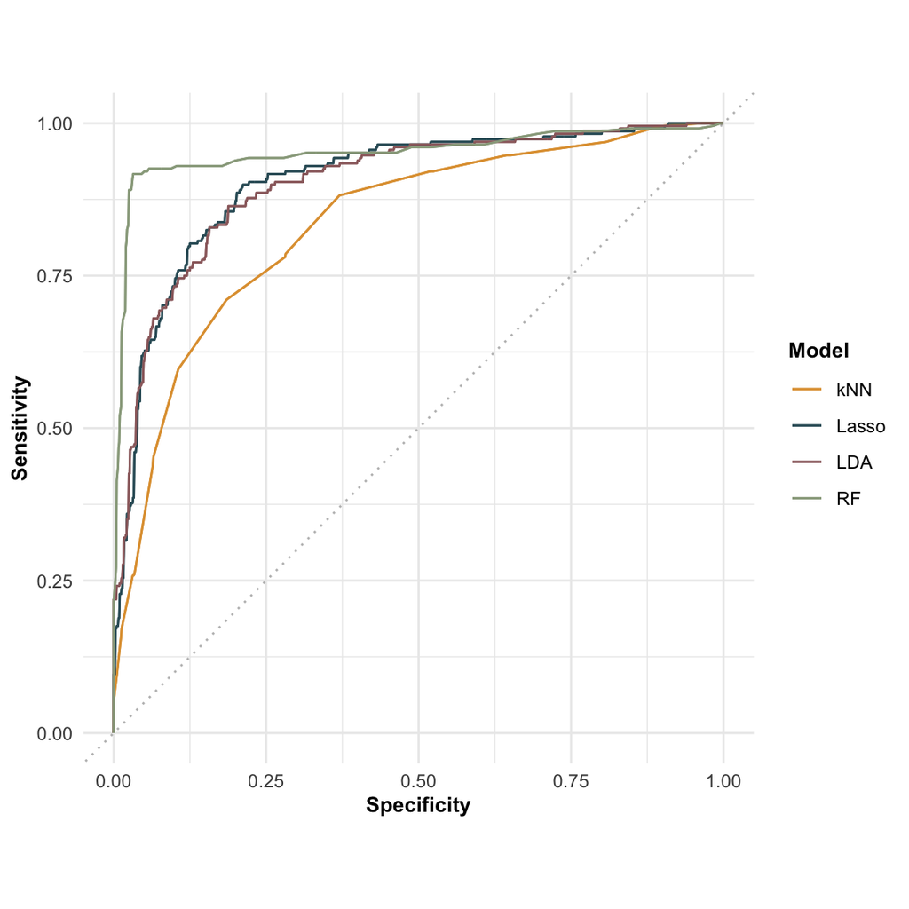

##### Figure 7. Model performance across all probability thresholds - Precision Recall (PR) curves

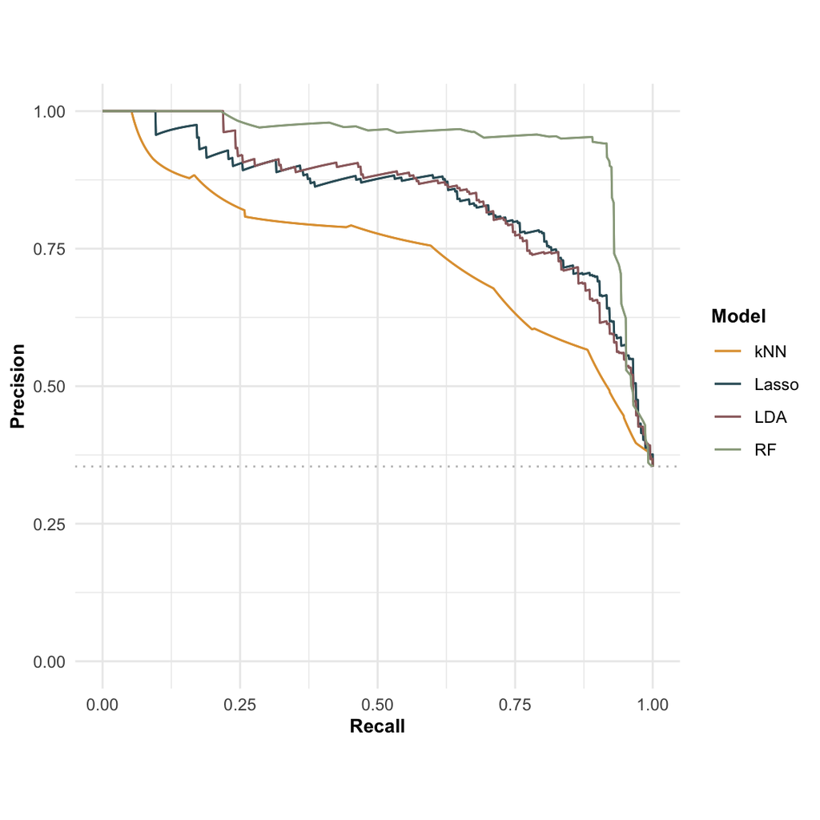

#### Feature Importance

The top features extracted from the RF model include Functional Assessment, ADL, and MMSE scores. These features are neurocognitive assessments performed by a clinician and help measure cognitive function and daily living abilities. These are directly related to Alzheimer’s disease [4]. The RF model suggesting these features are important in our model is consistent with medical understanding about Alzheimer’s.

##### Figure 8. Top 10 Important Features from RF Model

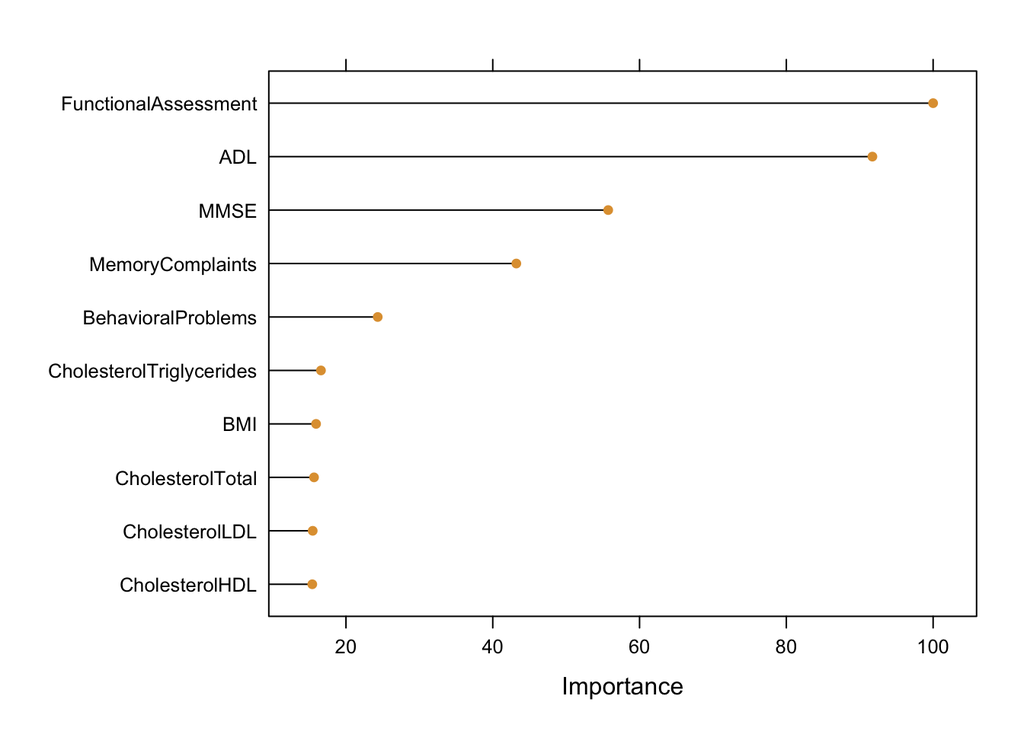

## Discussion and Conclusion

As we set out to find a right-sized model with adequate performance, we explored several classification algorithms and techniques and found the 100-tree Random Forest with cross-validation to be the best model for our problem. It outperformed all other models on all the performance metrics. We also were able to identify key features that can be associated with Alzheimer’s, such as Functional Assessment, ADL, and MMSE.

To evaluate our models, we began by focusing on Recall, as the cost of missing a patient with Alzheimer’s disease would have greater consequences compared to incorrectly classifying someone as having the disease. However, to balance Recall, we also looked for high Precision in our models because we did not want the models to cause unnecessary stress or diagnostic tests for patients. The PR curve visualises this trade-off between Recall and Precision, and showed the RF model as the superior model.

Despite leading performance metrics, we do recognise the potential shortcomings of our dataset and model: - The dataset is inherently imbalanced, which we have tried to adjust for in our model. - The number of observations in our dataset are limited, preventing us to train the model further. - The probability of misdiagnosing is not still not non-zero, that can have a significant impact on the misdiagnosed patient. - As the model was trained on synthetic dataset, it is yet to be validated on real-world patient data.

To develop our model further, we recommend the following as areas for future work and improvement on our research:

- **Validate and enhance with real patient clinical data.** Applying our RF model to real patient data would enable us to see if the model can perform in a clinical setting rather than with synthetic data. This would give a better evaluation of the model’s performance and increase its reliability. Furthermore, if we could even add additional patient clinical information, such as genetic test results, additional cognitive test scores, we could potentially improve the accuracy of our model but also gain greater insight into the variables that predict Alzheimer’s disease.
- **Introduce a qualified clinical expert in the loop.** Involving medical professionals who see Alzheimer’s disease patients on a daily basis is crucial, as they would be the ones that utilise our model. They can give insight on whether our predictors are relevant, provide real patient data, and see if our model is interpretable and understandable enough for them to use (not just from a machine learning perspective).
- **Advanced statistical methods.** We should investigate whether other machine learning algorithms, such as neural networks, are more effective at classification. We could also consider techniques like Bayesian optimisation to further tune our RF model, or add boosting techniques to enhance the current model. For feature importance evaluation, we could utilise SHAP values or LIME [5] which are more sophisticated methods.

In conclusion, our model can be the foundation to help people with early detection and intervention, leading to a healthier aging population globally, and for governments to develop better support system for people suffering with Alzheimer’s.

## Appendix

##### References

[1] Alzheimer’s Association, “Alzheimer’s Disease and Dementia,” [Online]. Available: https://www.alz.org/. [Accessed: 07-Nov-2024]  
[2] N. Japkowicz and S. Stephen, “The Class Imbalance Problem: A Systematic Study,” Intelligent Data Analysis, vol. 6, no. 5, pp. 429–449, 2002.  
[3] T. Hastie, R. Tibshirani, and J. Friedman, The Elements of Statistical Learning: Data Mining, Inference, and Prediction, 2nd ed. New York: Springer, 2009.  
[4] D. M. Schmitt, S. E. McCoy, J. C. Wichmann, and A. M. Iverson, “Functional decline in Alzheimer’s Disease: Correlation of ADL, Functional Assessment, and MMSE scores,” Alzheimer’s & Dementia: Translational Research & Clinical Interventions, vol. 2, no. 1, pp. 70-79, 2016. doi: 10.1016/j.dadm.2016.02.006.  
[5] DataCamp, “Introduction to Machine Learning in R.” DataCamp, 2024. [Online]. Available: https://www.datacamp.com/tracks/supervised-machine-learning-in-r

##### 1. Model performance with threshold set at 0.5

| Model | Accuracy | Recall | Precision | F1 |
| --- | --- | --- | --- | --- |
| Lasso | 0.70 | 0.70 | 0.82 | 0.76 |
| KNN | 0.76 | 0.44 | 0.79 | 0.57 |
| LDA | 0.83 | 0.74 | 0.77 | 0.76 |
| RF | 0.95 | 0.91 | 0.95 | 0.93 |